# cp2021-F05-Q01

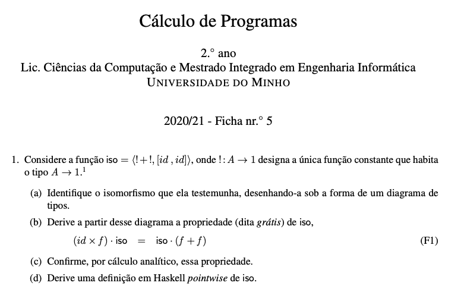

### Resolução (a)

$ A + A \cong (1 + 1) \times A \cong 2 \times A$

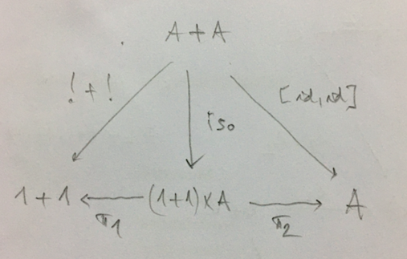

### Resolução (b)

$(id \times f) \ . iso = iso \ . (f + f)$

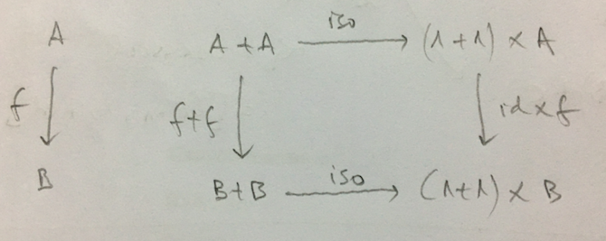

### Resolução (c)

$(id \times f) \ . iso = iso \ . (f + f)$

Sendo $ iso \ = \ <! + !, [id,id]>$ então, pela Lei da Troca, temos:

$(1) \ iso = \ < [ i_1 . !, i_2 . ! ], [ id, id ] >$

$(2) \ iso = \ [ < i_1 . !, id >, < i_2 . !, id > ]$

Vamos então mostrar que

$(id \times f) \ . iso = iso \ . (f + f)$

{ def-$\times$, **lei (10)** ; def-$+$, **lei (21)** }

$< id . \pi_1, f . \pi_2> \ . iso = iso \ . [i_1 . f, i_2 . f]$

{ fusão-$\times$, **lei (9)** ; fusão-$+$, **lei (20)** }

$< id . \pi_1 . iso, f . \pi_2 . iso> = [iso . i_1 . f, iso . i_2 . f]$

{ cancelamento-$\times$, **lei(7)** ; $\pi_1 . iso = [ i_1 . !, i_2 . ! ]$ ; $\pi_2 . iso = [ id, id ]$ }

$< id . [ i_1 . !, i_2 . ! ], f . [ id, id ] > = [iso . i_1 . f, iso . i_2 . f]$

{ cancelamento-$+$, **lei(18)** ; $iso . i_1 = < i_1 . !, id >$; $iso . i_2 = < i_2 . !, id >$ }

$< id . [ i_1 . !, i_2 . ! ], f . [ id, id ] > = [ < i_1 . !, id > . f, < i_2 . !, id > . f]$

{ natural-id, **lei (1)** ; fusão-$\times$, **lei (9)** ; fusão-$+$, **lei (20)** }

$< [ i_1 . !, i_2 . ! ], [ f, f ] > = [ < i_1 . ! . f, f > , < i_2 . ! . f, f > ]$

{ def. $! = \underline{()}$; natural-const, **lei (3)** }

$< [ i_1 . !, i_2 . ! ], [ f, f ] > = [ < i_1 . !, f > , < i_2 . !, f > ]$

{ lei da troca, **lei (28)** }

$[ < i_1 . !, f > , < i_2 . !, f > ] = [ < i_1 . !, f > , < i_2 . !, f > ]$

### Resolução (d)

$ iso = \ <! + !, [id,id]>$

{ def-$+$, **lei (21)** }

$\equiv iso = \ < [i_1 . !, i_2 . !], [id,id] >$

{ lei da troca, **lei (28)** }

$\equiv iso = \ [ < i_1 . !, id >, <i_2 . !, id > ]$

{ universal-$+$, $k=iso$ }

$ iso \ . i_1 = < i_1 . !, id >$

$ iso \ . i_2 = < i_2 . !, id >$

{ igualdade extensional, **lei (71)** }

$ (iso \ . i_1) \ a = < i_1 . !, id > \ a$

$ (iso \ . i_2) \ b = < i_2 . !, id > \ b$

{ def-comp, **lei (72)**, def-split, **lei (76)** }

$ iso \ (i_1 \ a) = ((i_1 . !) \ a, id \ a )$

$ iso \ (i_2 \ b) = ((i_2 . !) \ b, id \ b)$

{ natural-id, **lei (1)**; def-comp, **lei (72)** }

$ iso \ (i_1 \ a) = (i_1 (! \ a), a)$

$ iso \ (i_2 \ b) = (i_2 (! \ b), b)$

{ def. $! = \underline{()}$ }

$ iso \ (i_1 \ a) = (i_1 (), a)$

$ iso \ (i_2 \ b) = (i_2 (), b)$

### Haskell

```haskell
iso (Left a) = (Left (),a)
iso (Right b) = (Right (),b)

-- type checking

:t iso
```

iso :: forall b. Either b b -> (Either () (), b)